# Pile jacking example in Abaqus

Getting started with CEL simulations

Dominik Zobel

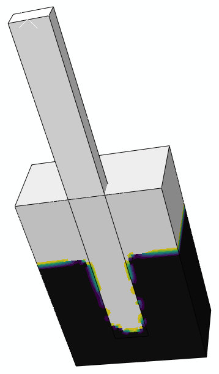

version: November 17, 2020

# 1 Getting started with Abaqus

Getting used to work with Abaqus may seem very difficult at the beginning. The program offers an overwhelming amount of possibilities—thus the appropriate workflow and the necessary options to simulate a certain problem may not be obvious at all. These notes are meant to help getting started with simulations at the Institute of Geotechnical Engineering and therefore focus on soil mechanics and soil-structure interaction.

There are various numerical methods which are more or less effective depending on the problem to investigate. Whenever soil undergoes great deformations, the *Finite Element Method* with an *Lagrangian* analysis may yield unreliable results due to distorted mesh sections or even fail to finish the calculation.

One approach, which is chosen for this tutorial, is to use the *Coupled Eulerian-Lagrangian* (CEL) method. Here, elements which are expected to flow or change their shape are modelled with Eulerian materials. The mesh of Eulerian elements will stay put and the material can flow within the element boundaries. If combined, Lagrangian and Eulerian elements are promising to model the interaction between soil and structure. In this document a simplified pile jacking CEL simulation will be conducted.

As this document was originally written in 2015, Abaqus 6.14 is used. Nevertheless, this tutorial (i. e. the workflow and all recommondations) is also valid for more recent versions like Abaqus 2020 (last tested version but even newer versions might work).

Upon starting, saving and during work Abaqus will create different files in the working directory.[^1] If the model is saved, a model file `<model>.cae` and a journal file `<model>.jnl` will be created or updated. Journal files contain all relevant Python commands for the actions taken to create the saved model. If no issues have to be corrected manually, they can be run to automatically recreate the model from scratch.[^2] After successfully creating a finished model, an input file `<model>.inp` is created. Input files contain all relevant model information and are required to calculate the results in Abaqus (on a local or remote machine). The finished results will be written to the model output database `<model>.odb` and can be inspected in Abaqus CAE or Viewer. Status reports and messages will be written to `<model>.dat`, `<model>.sta` and `<model>.msg`. Those files are especially useful, if the simulation fails.

Abaqus offers special solvers for certain kind of simulations. For soil-structure interaction (and many other soil mechanic investigations) the Standard/Explicit model option should be chosen in the start dialog (cf. figure 1.1). The decision between Standard and Explicit analysis will be postponed until chapter 6.

[figure not shown]

Figure 1.1: Start dialog of Abaqus 6.14.

Figure 1.2 shows the interface of Abaqus CAE. The *main menu* is located at the top of the window and has two lines of additional shortcut symbols. On the left hand side is the *model tree* and its nodes. By default, the initial model will be called `Model-1` and its child elements are visible.

The *viewport* on the right hand side displays the model. The model can be inspected, selected and manipulated within this area. At the left border of the viewport are two columns of symbols which will be called *Quick start symbols*. Different view modes can be chosen in the drop-down menu right of `Module` above the viewport. They can also be invoked by selecting the appropriate mode in the model tree.

Messages, warnings and errors are shown in the *message log* at the bottom part of Abaqus. Beneath the message log is also a *command line* (in the `>>>`-tab), where all commands (as shown in the journal file) can also be issued directly. In general, there are many options and commands in Abaqus, which can be invoked in more than one way.

[figure not shown]

Figure 1.2: Interface of Abaqus CAE. The main menu and two rows of shortcut symbols are near the top. The central area contains the model tree (left hand side) and the viewport (right hand side) with two columns of quick start symbols between both. The message log tab is located in the bottom area (in front of the command line tab).

The modules in Abaqus provie a workflow for model creation and simulation. They can either be changed by the drop-down menu named `Module` above the viewport or by clicking on the corresponding module in the model tree on the left.

At first, all required parts of the model are created individually in the *Part module* as described in chapter 2. All parts need to have material properties assigned to them, which will be covered in the *Material module* (chapter 3).

Afterwards the parts are assembled to the final model layout in the *Assembly module* (see chapter 4). After the assembly, necessary contact and interaction properties are defined (chapter 5) and boundary conditions as well as loads are defined and applied in the *Step module* (chapter 6).

Before continuing the parts have to be meshed in the *Mesh module* as described in chapter 7. Meshing can already be done after finishing the part geometries (chapter 2). However if partitions are added or changed in the assembly step, the mesh has to be redone.

In general, all modules can be edited (again) at any point, but sometimes the model has to be regenerated or otherwise updated to fit the changes.

In this document, all general Abaqus hints are highlighted like this.

When everything is done, a job can be created (see chapter 8) and the simulation can be run. Finally, the simulation results can be analyzed in the last module (chapter 9).

*Author’s remark:*

These notes are based on discussions with my colleagues from the Institute of Geotechnical Engineering at the Hamburg University of Technology. Additionally, the official Abaqus manual(s) (Dassault Systèmes 2014) as well as workshop slides (ABAQUS Inc. 2005) and the scripting notes from Overvelde (2010) were used.

# 2 Model creation

As Abaqus is starting, all required dependencies are loaded automatically for interactive work. But if a script with commands from a Journal- or Replay-file is run, these dependencies have to be imported at the beginning of the script.

```python
# -*- coding: utf-8 -*-
from part import *
from material import *
from section import *
from assembly import *
from step import *
from interaction import *
from load import *
from mesh import *
from optimization import *
from job import *
from sketch import *
from visualization import *
from connectorBehavior import *
```

## 2.1 Create pile object

Abaqus is providing an initial model called `Model-1` at startup. First, choose an expressive name to the model like *PileJackingModel*. Either right click on `Model-1` and select `Rename` or use the main menu (`Model->Rename->Model-1`). Notice the change in the model tree and in the second drop down menu above the viewport.[^3]

```python
mdb.models.changeKey(fromName='Model-1', toName='PileJackingModel');
```

Next, we create the parts of the model. To create a part, either right click on `Parts` and select `Create` in the model tree, select `Part->Create` in the main menu or use the Create Part icon () in the top left corner of the quick start symbols. The dialog box in figure 2.1 will open.

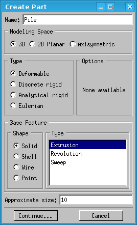

Figure 2.1: Create Part window. Assign a meaningful name to the part and decide its shape and type based on the requirements of the model.

Name the part *Pile* and accept the remaining default values. Since we are interested in a three dimensional analysis, 3D modelling space and a solid (deformable) shape are suitable. The approximate size and the type are used to create a sufficiently sized model out of a two dimensional sketch.

Using `Extrusion` simply extends the outline of the sketch in the third dimension. `Revolution` would revolve the sketch around an axis and `Sweep` allows an outline to follow a (closed) path.

The background of the viewport changes to a grid and the quick start symbol adapt to the `Sketch module`. To draw a sketch, simple geometric elements can be used. All options can either be executed using the main menu (`Add->`) or the quick start symbols.

A single point can be drawn (), a polyline (), a rectangle (), a circle () or an ellipse (). Circular arcs can be either drawn tangent to an existing line (), by a center point and two points on the arc () or by three points ().

All coordinates can either be chosen on the visual grid or inserted in the prompt at the bottom of the viewport (above message log). Commands can either be executed by pressing the Enter-key or the middle mouse button (MMB).

A sketch or its segments can also be moved with the cursor icon () or deleted by the eraser icon () in the lower region. To have a proper defined sketch/model, angles and lengths can and should be measured () and constraints imposed (). The constraints function opens a new window with a set of selectable constraints. Sometimes it might be more practical to draw freely and get the right model by measurements and constraints.

Everything can be changed or removed at almost any time, but sometimes not with obvious solutions like Ctrl+Z, Del or Esc.

Abaqus can also try to auto-constrain () and auto-measure () the sketch, but manually imposing at least some values and checking the validity is recommended. A simple rectangle with measurements and constraints representing the profile of the pile is shown in figure 2.2. Its area is 1 units ($x$-direction) by 0.5 units ($y$-direction).[^4]

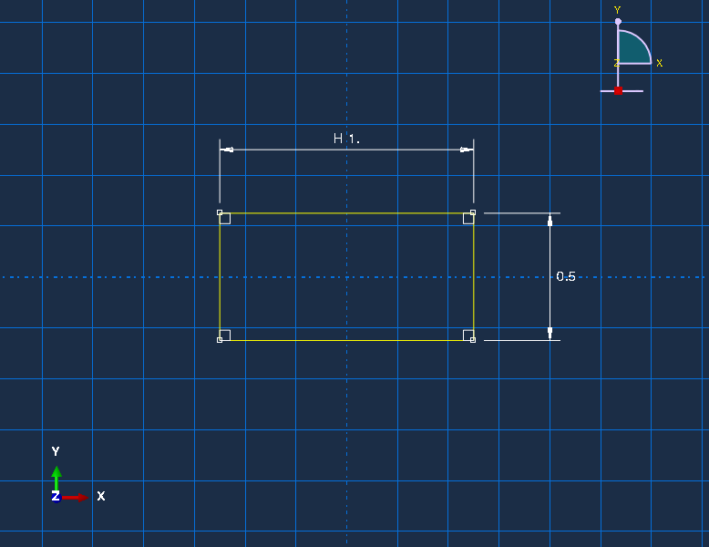

Figure 2.2: Finished sketch for pile in viewport, ready for extrusion.

When creating or manipulating objects, Abaqus will snap to the grid, to special points on the sketch and on all intersections.

This can be problematic when working on more complex geometry. As a consequence it may be favourable to draw a construction line () to create additional reference lines or artificial intersections to add additional segments more easily.

Some icons like this have more options to choose from, as hinted by the small black triangle in the lower right corner. Left click on such icons and hold the left mouse button pressed to see all available options. Release above the icon of choice to select it. The last selected symbol will be shown among the quick start symbols.

There are five ways to define a construction line (): Either by two points, or by one point (with horizontal or vertical constraint), or by one point and an angle or as a circle (by defining center point and radius).

If the functionality of an option is not known, move the mouse above the icon. An info box will appear with its name/description.

Another useful function is auto-trimming (). Its main use is the removal of single segments between corners or intersections and will be very useful with more complex geometry made from/with simple elements.

The finished sketch will be extruded to become a part. On exiting the sketch editor the Extrude dialog opens (cf. figure 2.3). Set the depth of extrusion to 10 units and confirm. The main window should now look like figure 2.4.

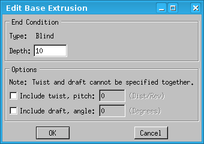

Figure 2.3: Extrusion dialog. Besides extruding, a twist can be added to generate a screw (not used in this tutorial).

[figure not shown]

Figure 2.4: Main window after creating the pile part.

All commands used to create the pile are listed below. First, a `ConstrainedSketch` element is created and a rectangle, defined by two points, upon it. In Line 23 and 26 measurements are added by `HorizontalDimension` and `VerticalDimension` commands.[^5] When the sketch is finished, name, shape and type options as seen in figure 2.1 are chosen. When everything is applied and the part is successfully created, the temporary `ConstrainedSketch` is removed.[^6]

```python
drawing = mdb.models['PileJackingModel'].ConstrainedSketch(name='__profile__', sheetSize=20.0);
drawing.rectangle(point1=(-0.5, -0.25), point2=(0.5, 0.25));
drawing.HorizontalDimension(textPoint=(0.0, 0.5), value=1.0,
   vertex1=drawing.vertices.findAt((-0.5, 0.25), ),
   vertex2=drawing.vertices.findAt((0.5, 0.25), ));
drawing.VerticalDimension(textPoint=(0.75, 0.0), value=0.5,
   vertex1=drawing.vertices.findAt((0.5, -0.25), ),
   vertex2=drawing.vertices.findAt((0.5, 0.25), ));
partPile = mdb.models['PileJackingModel'].Part(dimensionality=THREE_D, name='Pile',
   type=DEFORMABLE_BODY);
partPile.BaseSolidExtrude(depth=10.0, sketch=drawing);
del drawing;
```

## 2.2 Create soil object

Now the soil part has to be modelled. The procedure is almost the same as described for the pile in the previous section. Create a new part and name it *Soil*. To make it an Eulerian part, choose the Eulerian type instead of Deformable in the Create Part window and accept the other default options. The sketch editor will open again and another rectangular profile should be made. This time the dimensions are 4 units ($x$-direction) by 2 units ($y$-direction) and an extrusion depth of 6 units ($z$-direction).

As always, save often to prevent the trouble of losing data.

As a result the part should look like the one shown in figure 2.5. Here the element tree is expanded and in both parts a `Solid extrude-1` element and a `Section Sketch` element can be seen. Right click on `Section Sketch` and choose `Edit` to change the sketch of the element or edit `Solid extrude-1` to change the extrusion depth. If any changes are made in these settings, the whole part has to be regenerated, as a warning window will indicate. Right click on `Features` and select `Regenerate` of the corresponding part. Alternatively activate the corresponding part—if not active—and choose `Feature->Regenerate` from the main menu.

Active models/parts/instances/… are underlined. To activate an inactive element double click on it.

[figure not shown]

Figure 2.5: Main window after creating the soil part. The model tree is expanded, the soil part is active and the child elements for sketch and extrusion control can be seen.

It should not be surprising, that the journal data for the soil element is very similar to the pile part. The most important difference is the Eulerian part type (line 43-44).

```python
drawing = mdb.models['PileJackingModel'].ConstrainedSketch(name='__profile__', sheetSize=20.0);
drawing.rectangle(point1=(-2.0, -1.0), point2=(2.0, 1.0));
drawing.HorizontalDimension(textPoint=(0.0, 1.5), value=4.0,
   vertex1=drawing.vertices.findAt((-2.0, 1.0), ),
   vertex2=drawing.vertices.findAt((2.0, 1.0), ));
drawing.VerticalDimension(textPoint=(2.5, 0.0), value=2.0,
   vertex1=drawing.vertices.findAt((2.0, -1.0), ),
   vertex2=drawing.vertices.findAt((2.0, 1.0), ));
partSoil = mdb.models['PileJackingModel'].Part(dimensionality=THREE_D, name='Soil',
   type=EULERIAN);
partSoil.BaseSolidExtrude(depth=6.0, sketch=drawing);
del drawing;
```

## 2.3 Adding and querying elements

This section applies to the `Part module` and the `Assembly module` described in chapter 4. In both modules it may be necessary to create special elements or to obtain information about the geometry. To obtain node coordinates or the distance between nodes—as well as many other useful information—select `Tools->Query` from the main menu and the Query window will open (cf. left side of figure 2.6).

Sometimes it is useful to create *datum points*, *axis* or *planes* to ease working with partitions or assembling elements later on. To create a datum element, either select `Tools->Datum` from the main menu to open the Create Datum window (cf. center of figure 2.6) or use the quick start symbols (lower midarea). You can create a datum point (), a datum axis() or a datum plane (). All datum elements can be created in different ways (hence the black triangle in the lower right corner of the icon).

*Reference points* are similar to datum points, but offer more possibilities. They can be coupled to geometric entities (e. g. sets, parts and instances) to define boundary conditions (movement, loads, …) or obtain measurement data. To create a reference point, use `Tools->Reference Point` from the main menu.

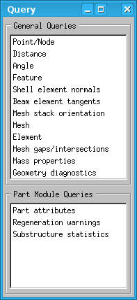

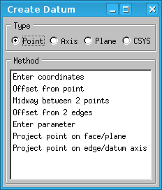

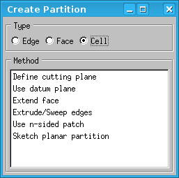

Figure 2.6: Query dialog on the left hand side and Create Datum window (with datum point options visible) in the center. The Create Partition window (with cell option) can be seen on the right hand side.

*Sets* in turn are useful to label elements or whole parts. This can be very helpful when imposing boundary conditions or other constraints on (parts of) a geometry. Sets can either be created by selecting `Tools->Set->Create` in the main menu or by right clicking on `Sets` in the model tree and choosing `Create`.

*Partitions* are essential for multiple material assignments and important for mesh generation. The Create Partition window can be invoked by `Tools->Partition` (cf. right hand side of figure 2.6).

Additionally, quick start symbols (central, above datum icons) are also available e. g. for creating cell partitions () or face partitions (). It can be useful to sketch and create a face partition and extrude the partition through the cell(s) afterwards ().

Eulerian material can only flow within the given geometry. Therefore creating and assigning partitions with different materials (and void material) may be useful.

### Adjusting the pile part

These concepts should now be applied to the PileJackingModel. First, a reference point should be added to control the pile movement later on. Add it at the middle of longest edge on the top of the pile as shown in figure 2.7 and name it *RP_Pile*.

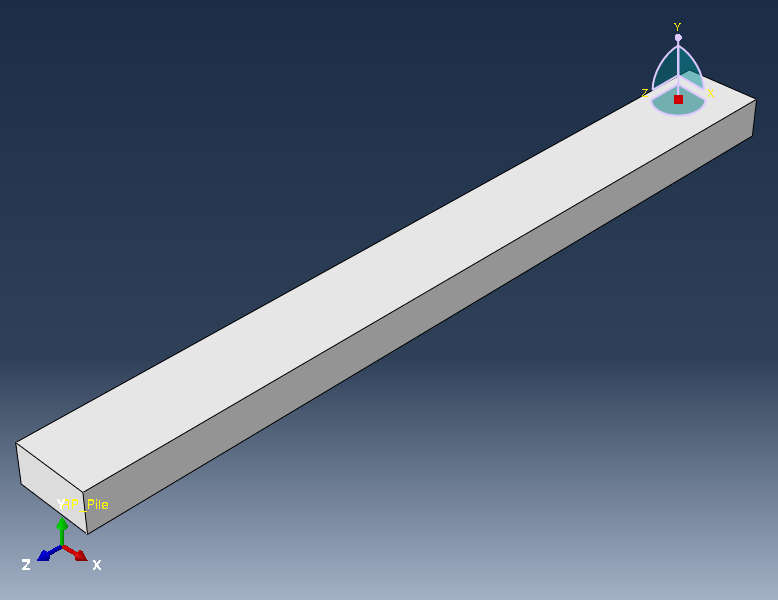

Figure 2.7: Pile with reference point at middle of longest edge on top.

```python
rp = partPile.ReferencePoint(point=(0.0, -0.25, 10.0));
partPile.features.changeKey(fromName='RP', toName='RP_Pile');
```

Then two sets should be added for the pile: The whole part (without the reference point) should be represented as a *setAll* as well as the reference point as *setRP*.

```python
partPile.Set(name='setAll', cells=partPile.cells);
partPile.Set(name='setRP', referencePoints=(partPile.referencePoints[rp.id], ));
```

### Adjusting the soil part

Next, the soil should be partitioned (e. g. by cutting planes). One possibility to get the desired cutting plane is to create necessary datum point(s) first, which are on this plane.[^7] In chapter 3, the lower two thirds of the soil volume will be filled with a sand material while the top third will contain void material. Additionally, the mesh of the soil around the pile should be denser than in the area farther away to have a better representation of the Eulerian volume near the pile.

So one partition should divide the soil in two equal parts in $y$-direction and two more partitions should separate the outer fourth in $x$-direction.[^8] In the end, a result similar to figure 2.8 should be achieved.

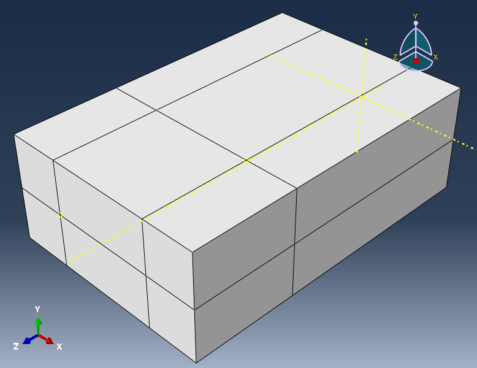

Figure 2.8: Soil element partitioned by four cutting planes.

In this scenario, two datum points are sufficient if correctly chosen. Additionally the three principal datum axis should be created.[^9]

```python
pt1 = partSoil.DatumPointByCoordinate(coords=(1.0, 1.0, 4.0));
pt2 = partSoil.DatumPointByCoordinate(coords=(-1.0, 0.0, 6.0));
xaxis = partSoil.DatumAxisByPrincipalAxis(principalAxis=XAXIS);
yaxis = partSoil.DatumAxisByPrincipalAxis(principalAxis=YAXIS);
zaxis = partSoil.DatumAxisByPrincipalAxis(principalAxis=ZAXIS);
```

The Partition can be created by a cutting plane. If one point on the plane is known and a normal can be selected, the option Point and Normal can be chosen.

```python
partSoil.PartitionCellByPlanePointNormal(cells=partSoil.cells,
   normal=partSoil.datums[xaxis.id], point=partSoil.datums[pt1.id]);
partSoil.PartitionCellByPlanePointNormal(cells=partSoil.cells,
   normal=partSoil.datums[zaxis.id], point=partSoil.datums[pt1.id]);
partSoil.PartitionCellByPlanePointNormal(cells=partSoil.cells,
   normal=partSoil.datums[xaxis.id], point=partSoil.datums[pt2.id]);
partSoil.PartitionCellByPlanePointNormal(cells=partSoil.cells,
   normal=partSoil.datums[yaxis.id], point=partSoil.datums[pt2.id]);
```

Finally, some sets should be created for the soil part. The whole part should also be represented as a set (*setAll*). Next, all cells in the upper third should form *setCellsTop* and all cells in the two lower thirds *setCellsBottom*. Then, all (8) boundary faces in $x$-direction should be gathered in *setFacesX*, all (12) boundary faces in $y$-direction in *setFacesY* and all (6) bottom boundary faces in *setFacesBottom*.[^10]

When using mouse selection to create sets, the vertices adjoining other cells outside the intended set mustn’t be selected, but all edges and faces within.

```python
partSoil.Set(cells=partSoil.cells, name='setAll');
cellstop = partSoil.cells[0:0];
cellsbottom = partSoil.cells[0:0];
for singlecell in partSoil.cells:
   if (singlecell.pointOn[0][2] > 4.0):
      cellstop += partSoil.cells[singlecell.index:singlecell.index+1];
   else:
      cellsbottom += partSoil.cells[singlecell.index:singlecell.index+1];
#
partSoil.Set(cells=cellstop, name='setCellsTop');
partSoil.Set(cells=cellsbottom, name='setCellsBottom');
facesX = partSoil.faces[0:0];
facesY = partSoil.faces[0:0];
facesbottom = partSoil.faces[0:0];
for singleface in partSoil.faces:
   if (singleface.pointOn[0][2] <= 0.0):
      facesbottom += partSoil.faces[singleface.index:singleface.index+1];
   if (abs(singleface.pointOn[0][0]) >= 2.0):
      facesX += partSoil.faces[singleface.index:singleface.index+1];
   if (abs(singleface.pointOn[0][1]) >= 1.0):
      facesY += partSoil.faces[singleface.index:singleface.index+1];
#
partSoil.Set(faces=facesX, name='setFacesX');
partSoil.Set(faces=facesY, name='setFacesY');
partSoil.Set(faces=facesbottom, name='setFacesBottom');
```

Sometimes a single part is too complex to be represented by a simple sketch. But Abaqus supports creating complex part out of multiple simple parts in the assembly as mentioned in chapter 4. Also, geometry can be created in a different program and imported in Abaqus (`File->Import->Part`).

# 3 Material assignment

Enter the `Material module` by either right clicking on `Materials` in the model tree and selecting `Switch context`, or by choosing the `Property` entry in the Module drop-down menu above the viewport. Many quick start symbols change, but the datum and partition option (as well as the feature options which aren’t discussed here) stay the same.

First, we define a new material by either clicking on () or right clicking on `Materials` in the model tree and selecting `Create` or by choosing `Material->Create` in the main menu to open the Edit Material window.

Our first material will be steel. After naming the material, several options can be added to define its behavior. Most importantly its density (`General->Density`) and its elastic properties (`Mechanical->Elasticity->Elastic`). As hinted in section 2.1:

All dimensional values need to have fitting units. Choose a consistent system like the SI or the Geotechnics system as shown in table 3.1.

Table 3.1: Consistent unit systems

| System | Length | Force | Mass | Time | Stress | Energy | Density |
| --- | --- | --- | --- | --- | --- | --- | --- |
|  | [$\mathsf{L}$] | [$\frac{\mathsf{ML}}{\mathsf{T}^2}$] | [$\mathsf{M}$] | [$\mathsf{T}$] | [$\frac{\mathsf{M}}{\mathsf{LT}^2}$] | [$\frac{\mathsf{ML}^2}{\mathsf{T}^2}$] | [$\frac{\mathsf{M}}{\mathsf{L}^3}$] |
| SI | m | N | kg | s | Pa ($\frac{\text{N}}{\text{m}^2}$) | J | $\frac{\text{kg}}{\text{m}^3}$ |
| Geotechnics | m | kN | t | s | kPa ($\frac{\text{kN}}{\text{m}^2}$) | kJ | $\frac{\text{t}}{\text{m}^3}$ |

This example will use the Geotechnics system. Every unit for previously set lengths for the model parts created in chapter 2 will be regarded as meters. Accordingly to this unit system, the value for the density of steel will be 7.87 t/m$^3$, the Young’s modulus $210\cdot 10^6$ kPa and Poisson’s ratio 0.3. Enter these values in the respective property tab (cf. figure 3.1) and click `Ok` to save the properties and close the window.

```python
mdb.models['PileJackingModel'].Material(name='steel');
mdb.models['PileJackingModel'].materials['steel'].Density(table=((7.87, ), ));
mdb.models['PileJackingModel'].materials['steel'].Elastic(table=((210e6, 0.3), ));
```

Now the sand material has to be defined in the same way. Its density is 1.6 t/m$^3$ and it is assumed to be linear elastic (Young’s modulus $30\cdot 10^3$ kPa and Poisson’s ratio 0.25).

```python
mdb.models['PileJackingModel'].Material(name='sand');
mdb.models['PileJackingModel'].materials['sand'].Density(table=((1.6, ), ));
mdb.models['PileJackingModel'].materials['sand'].Elastic(table=((30e3, 0.25), ));
```

If a user defined material behavior (e. g. hypoplastic behaviour) should be simulated, the amount of solution-dependent variables has to be defined (`General->Depvar`) and the values given to the user routine (`General->User Material`) as shown on the right hand side of figure 3.1. This will not be used in this tutorial.

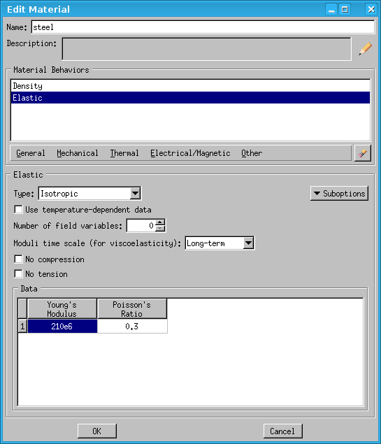

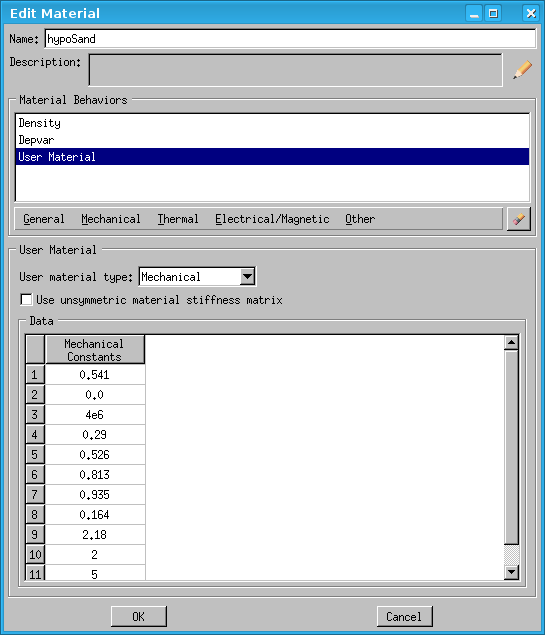

All necessary materials are defined and after creating sections, they can be applied to the geometry. So for all parts, a new section is created by either right clicking on `Sections` in the model tree and choosing `Create`, selecting `Section->Create` in the main menu or using the quick start symbol ().

As the Create Section window opens, the material name, type and category can be edited. Choose *secPile* for the section associating the steel material with the pile geometry. Since the pile geometry is homogeneous and solid, no changes are necessary here. Clicking on `Continue` opens the Edit Section window (cf. figure 3.2).

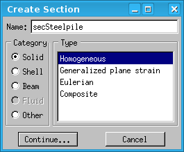

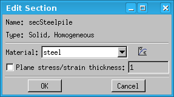

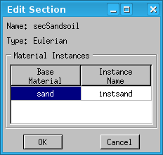

```python
mdb.models['PileJackingModel'].HomogeneousSolidSection(name='secPile', material='steel',
   thickness=None);
```

Figure 3.2: The Section Create on the left hand side and two Section Edit dialogs. The dialog in the center is called when homogeneous types are chosen, the dialog on the right hand side for Eulerian types.

Repeat the process but this time name the section *secSoil* and choose an Eulerian type. This time a base material has to be chosen in the Edit Section window.

```python
mdb.models['PileJackingModel'].EulerianSection(name='secSoil', data={'instsand': 'sand'});
```

Finally the material sections have to be assigned to the geometry. To assign the pile geometry to the steel material, make the pile the active element (underlined name) and choose `Assign->Section` in the main menu, right click on `Section Assignments` and selecting `Create` or by the quick start symbol (). A new region can be selected or a previously defined set can be loaded below the viewport. Click on `Sets` to select the *setAll* set.

Choose the appropriate section (*secPile*) in the section drop-down menu of the Edit Section Assignment window and the assignment is complete. (see left hand side of figure 3.3). Only applicable sections will be displayed and can be assigned.

Correctly assigned geometry will change its color from grey to pale green.

Generally, the assignment procedure should be repeated for all other elements. When dealing with Eulerian elements (like this soil element), the region is set automatically and a new set is created when an Eulerian material is defined.[^11] [^12] Eulerian elements can have different materials, which have to be assigned as a predefined field (see chapter 6), but the basic material assignment is done.

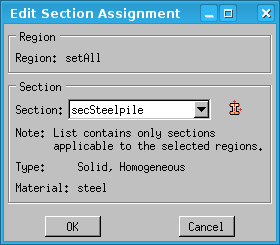

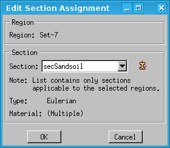

```python
partPile.SectionAssignment(sectionName='secPile', region=partPile.sets['setAll'], offset=0.0,
   offsetField='', offsetType=MIDDLE_SURFACE, thicknessAssignment=FROM_SECTION);
partSoil.SectionAssignment(sectionName='secSoil', region=partSoil.sets['setAll'], offset=0.0,
   offsetField='', offsetType=MIDDLE_SURFACE, thicknessAssignment=FROM_SECTION);
```

Figure 3.3: Section Assignment of steel material for pile and sand material for soil.

# 4 Assembly

After all parts are finished, the model itself can be assembled. Either right click on `Assembly` in the model tree and select `Switch Context` or choose `Assembly` from the drop-down menu named `Module` above the viewport. The quick start symbols contain eight special assembly icons and some already known ones (features, datums and partitions).

An assembled model (represented in blue) consists of different instances. One instance can be made from one part, but one part can also be used to create multiple instances. All instances can be transformed (rotation and translation) and aligned with others.

To create an instance, either right click on `Instances` in the model tree and select `Create`, choose `Instance->Create` in the main menu or click on the quick start symbol (). Select both parts in the Create Instance window and click `Ok` (cf. figure 4.1).[^13]

```python
mdb.models['PileJackingModel'].rootAssembly.DatumCsysByDefault(CARTESIAN);
instPile = mdb.models['PileJackingModel'].rootAssembly.Instance(name='instPile', part=partPile,
   dependent=ON);
instSoil = mdb.models['PileJackingModel'].rootAssembly.Instance(name='instSoil', part=partSoil,
   dependent=ON);
```

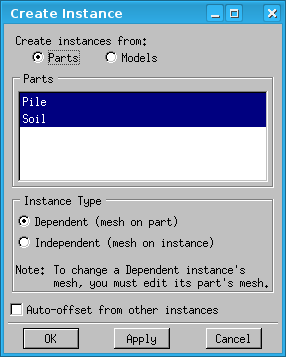

Figure 4.1: Create instance window with both parts selected.

Now the instances have to be transformed to get the right model composition. The initial coordinates of the instances are dependent on the corresponding part coordinates. So considering the part’s position in the model when creating it makes assembling the model more convenient.

Later on, the upper third of the soil volume will contain void material and the rest will be filled with sand material. The pile should be positioned just above the soil (aligned with the plane of the horizontal partition), centered in $x$-direction and at the back of the soil in $y$-direction like in figure 4.2.

[figure not shown]

Figure 4.2: Final assembly of pile and soil geometry.

To translate an instance, either choose `Instance->Translate` from the main menu or use the quick start symbol (). After selecting the instance(s) to translate, either select start and end point in the viewport or input the coordinates. When using coordinate input, only the relative vector is important.[^14]

```python
mdb.models['PileJackingModel'].rootAssembly.translate(instanceList=('instPile', ),
   vector=(0.0, -0.75, 4.0));
```

If a rotation should to be applied, either choose `Instance->Rotate` from the main menu or use the quick start symbol (). A rotation axis by two points has to be defined, before the rotation angle can be chosen.

Another important function for the model setup is to add geometric constraints between instances (). Either choose an option from `Constraint->` in the main menu or use one of the seven quick start symbols () to make faces parallel, move face to face, make edges parallel, move edge to edge, make elements coaxial, coincident point or make some CSYS[^15] parallel.

Sometimes a sketched part in the `Part module` cannot be made as complex as needed, but all geometric features can be created separately. The complex structure can be assembled in the `Assembly module` by translating, rotating and aligning all parts involved. Using the Merge/Cut function (`Instance->Merge/Cut`) or the quick start symbol (), a new and more complex part can be created from those instances and used thereafter.

# 5 Interactions and constraints

General interactions and constraints are accessible in the `Interaction module` in the `Module` drop-down menu above the viewport or by right clicking on either `Interactions` or `Constraints` in the model tree and choosing `Switch Context`.

As a first constraint, all movement and velocity (as defined in chapter 6) of the pile should be controlled by the reference point *RP_Pile*. A quick start symbol for creating reference points () is available in this module, but we have already defined one.

To create a constraint, either click on the quick start symbol (), right click on `Constaints` in the model tree and choose `Create` or select `Constraint->Create` from the main menu. The Create constraint window will open and in this case, a `Rigid body` constraint should be applied, since the pile is much stiffer than the soil and its deformations are negligible in comparison. As an advantage, the simulation will finish sooner as if the steel pile deformations (and therefore the degrees of freedom of each individual node of the pile) were considered.

To define the `Rigid body` constraint, a (body) region and a reference point have to be selected by clicking on the cursor symbol. Since the pile and the reference point are already defined as sets, these definitions can be used (cf. figure 5.1).

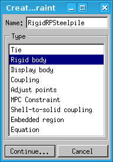

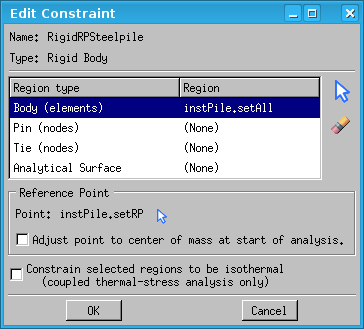

Figure 5.1: The Create Constraint window on the left hand side and the Edit Constraint window on the right hand side.

```python
mdb.models['PileJackingModel'].RigidBody(bodyRegion=instPile.sets['setAll'],
   name='RigidRPSteelpile', refPointRegion=instPile.sets['setRP']);
```

All elements or surfaces which (could or should) interact with each other need to have definitions for contact and interaction. Therefore an interaction is added by either selecting `Interaction->Create` in the main menu, the quick start symbol () or by right clicking on `Interactions` in the model tree and choosing `Create`. The Create Interaction window will open as shown in the left hand side of figure 5.2.

Some interactions can be used for Standard and Explicit analysis, but others only for one. For simple FEM examples, surface-to-surface contact is often the best choice, but a simpler (and computationally more expensive way) is General contact. This example will use an Explicit analysis where Eulerian and Lagrangian elements interact (CEL). Therefore General contact (Explicit) has to be selected.

The interactions and the steps in the next chapter have to be chosen consistent with the type of analysis to be done.

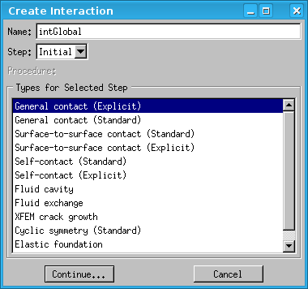

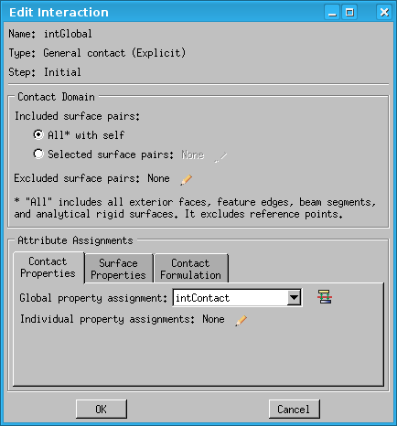

Figure 5.2: The Create Interaction window on the left hand side and the Edit Interaction window after defining the interaction property on the right hand side.

For this General contact example, the interaction should be able to have contact with any other element (select `All * with self` option) Now a global property assignment has to be defined, before the interaction can be created.

Click on the Create Interaction Property icon () and select Contact to define a contact interaction property.[^16] To simulate the mechanical interaction between the instances, the normal contact behaviour (`Mechanical->Normal behavior`) and the tangential contact behavior (`Mechanical->Tangential behavior`) should be added.[^17]

In this example the default options for both will do, i. e. frictionless behaviour in tangential direction and hard contact in normal direction (cf. figure 5.3). The resulting model is shown in figure 5.4.

Small circles on the respective geometry symbolize applied constraints.

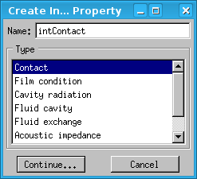

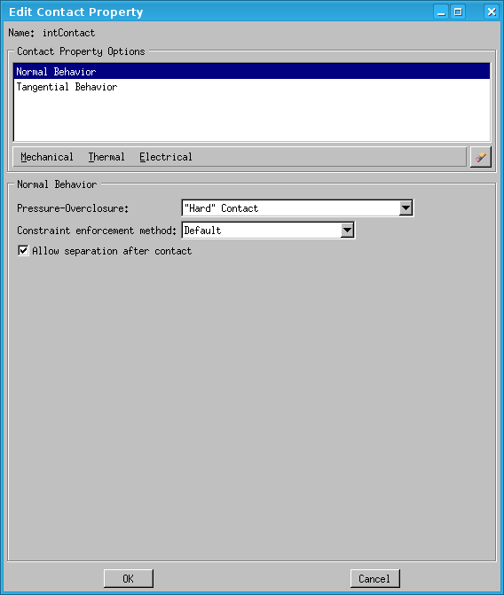

Figure 5.3: The Create Interaction Property window on the left hand side and the Edit Contact Property window on the right hand side.

[figure not shown]

Figure 5.4: Abaqus window after applying the interactions and constraints.

```python
mdb.models['PileJackingModel'].ContactProperty('intContact');
mdb.models['PileJackingModel'].interactionProperties['intContact'].NormalBehavior(
   allowSeparation=ON, constraintEnforcementMethod=DEFAULT, pressureOverclosure=HARD);
mdb.models['PileJackingModel'].interactionProperties['intContact'].TangentialBehavior(
   formulation=FRICTIONLESS);
mdb.models['PileJackingModel'].ContactExp(createStepName='Initial', name='intGlobal');
mdb.models['PileJackingModel'].interactions['intGlobal'].includedPairs.setValuesInStep(
   stepName='Initial', useAllstar=ON);
mdb.models['PileJackingModel'].interactions['intGlobal'].contactPropertyAssignments.appendInStep(
   assignments=((GLOBAL, SELF, 'intContact'), ), stepName='Initial');
```

# 6 Steps

## 6.1 Creating steps

After the model geometry is set, it is time to define and apply boundary conditions and loads on the model in the `Step module`. This module can be accessed by either right clicking on `Steps` and choosing `Switch context` in the model tree or choosing `Step` in the `Module` drop-down menu above the viewport.

Steps are created to define a sequence of actions performed on the model. A model always has an initial step to define an original state. It is also possible to define boundary conditions, more interactions and predefined fields for this first step. Every additional step has to have a duration[^18] and can define custom loads.

To create a new step, either click on `Steps` and choose `Create` in the model tree, select `Step->Create` from the main menu or click on its quick start symbol (). The Create Step window will open (cf. figure 6.1).

The first step will be named *Preparation* and can be used to set up initial loads like gravity. In this example, its type should be set to `Dynamic, Explicit` to be compatible with the next step. In the Edit Step window, an optional description can be inserted and the time period has to be chosen (here 0.1 s).

Now the same procedure has to be repeated for another `Dynamic, Explicit` step named *PileJacking*, where the pile will be driven into the soil within 3 s. A reasonable duration is depending on the loads applied in a step, especially if they are explicitly time dependent (like velocities).

The decision whether to use `Standard` or `Explicit` analysis is depending on the problem itself. As a rule of thumb, `Explicit` is favored for large, nonlinear problems, fast dynamics, or problems with significant discontinuities, while `Standard` is rather used for linear (dynamic) and nonlinear static problems (cf. ABAQUS Inc. 2005). To use the CEL method with Lagrangian and Eulerian elements, `Explicit` has to be chosen.

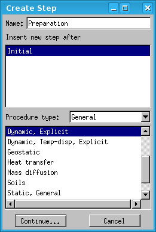

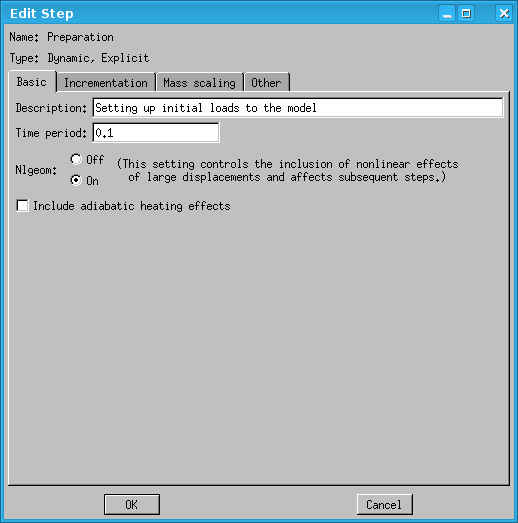

```python
mdb.models['PileJackingModel'].ExplicitDynamicsStep(name='Preparation', previous='Initial',
   description='Preparation step', timePeriod=0.1);
mdb.models['PileJackingModel'].ExplicitDynamicsStep(name='PileJacking', previous='Preparation',
   description='Jacking the pile into the soil', timePeriod=3.0);
```

Figure 6.1: The Create Step window and the Edit Step window for the *Preparation* step.